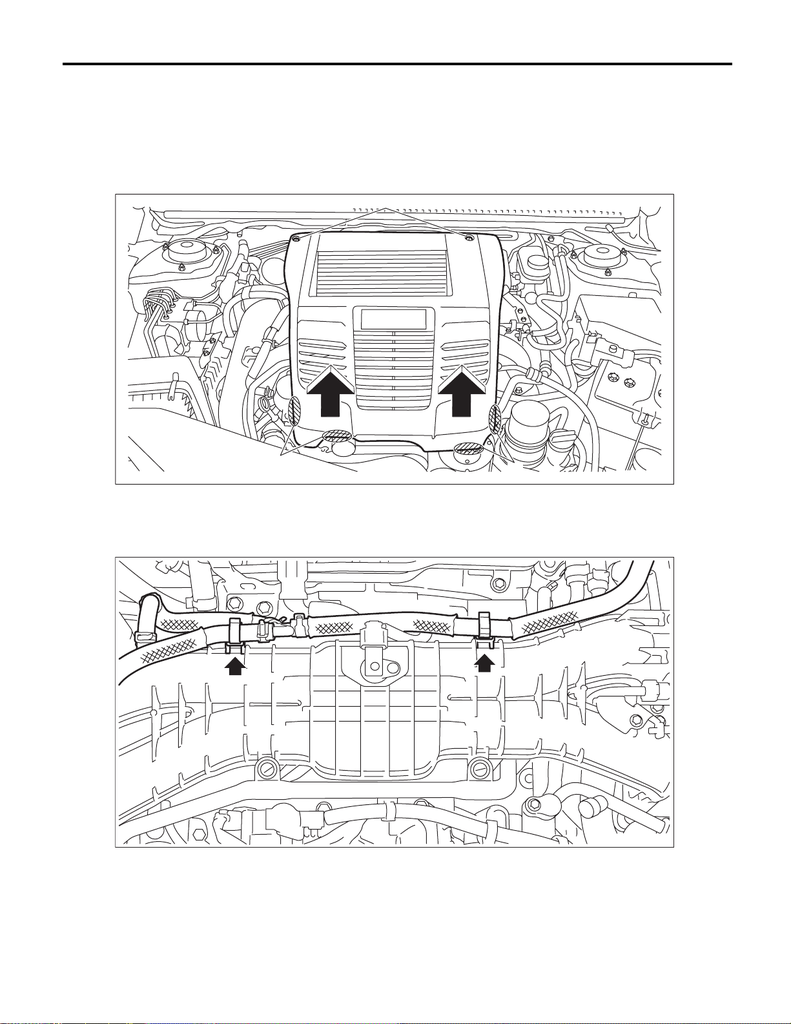

EC(w/o STI)-32

EGR Pipe

EMISSION CONTROL (AUX. EMISSION CONTROL DEVICES)

6. EGR Pipe

A: REMOVAL

1) Remove the collector cover.

(1) Remove the clips (A).

(2) Hold the shaded area (B) by hand and carefully pull the RH side (C) upward.

(3) Hold the shaded area (D) by hand and carefully pull the LH side (E) upward.

2) Disconnect the ground terminal from battery sensor. <Ref. to NT-5, BATTERY, NOTE, Note.>

3) Remove the intercooler. <Ref. to IN(w/o STI)-38, REMOVAL, Intercooler.>

4) Remove the clip securing the brake booster vacuum hose to the intake manifold, and move the brake

booster vacuum hose at the locations that do not interfere operation.

EX-03204

(A)

(B)

(C)

(E)

(D)

EC-03455

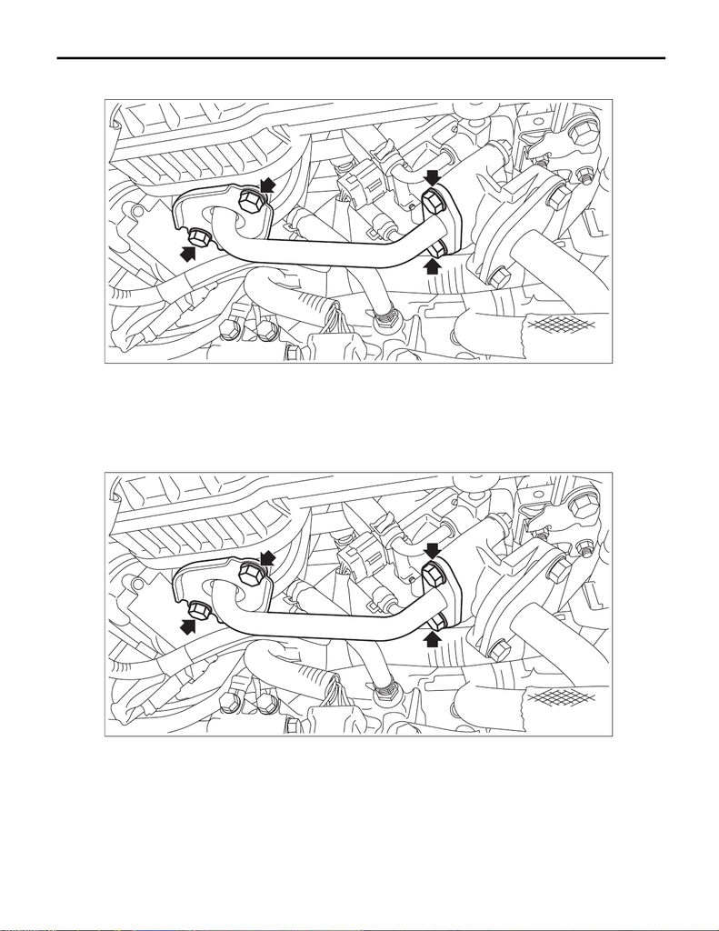

EC(w/o STI)-33

EGR Pipe

EMISSION CONTROL (AUX. EMISSION CONTROL DEVICES)

5) Remove the bolts which secure the EGR pipe to the intake manifold and EGR control valve, and remove

the EGR pipe.

B: INSTALLATION

1) Install the EGR pipe to the intake manifold and EGR control valve.

(1) Set the EGR pipe to the intake manifold and EGR control valve, and temporarily tighten the bolts

which secure the EGR pipe to the intake manifold and EGR control valve.

NOTE:

Use new gaskets and O-rings.

EC-03139

EC-03139

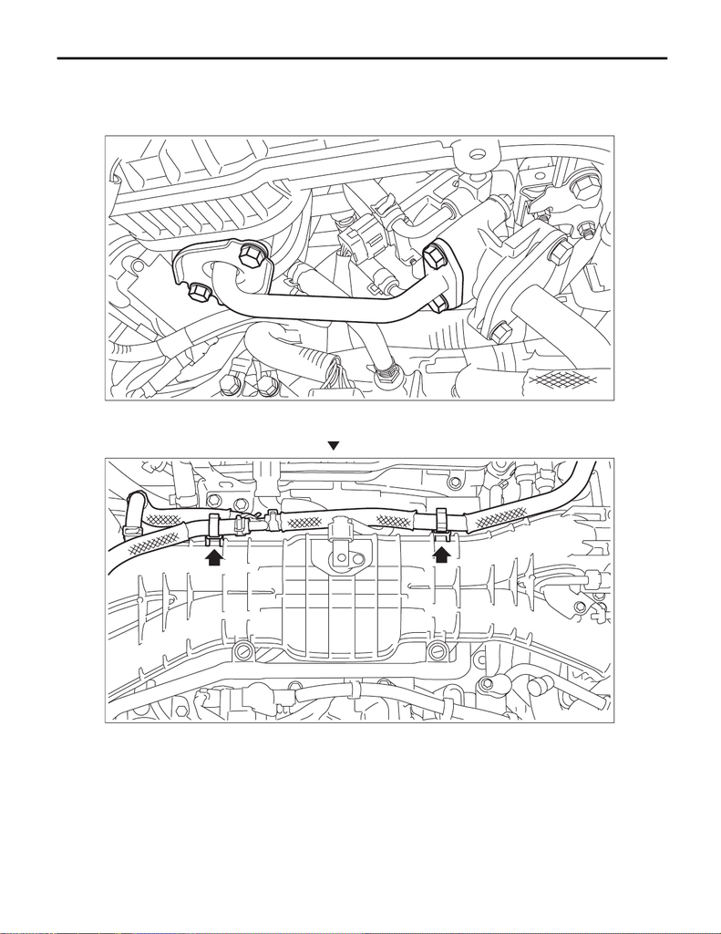

EC(w/o STI)-34

EGR Pipe

EMISSION CONTROL (AUX. EMISSION CONTROL DEVICES)

(2) Tighten the bolts which secure the EGR pipe to the intake manifold and EGR control valve in numer-

ical order as shown in the figure.

Tightening torque:

19 N·m (1.9 kgf-m, 14.0 ft-lb)

2) Install the clip which secures the brake booster vacuum hose to the intake manifold.

NOTE:

Install the clip to the position of alignment mark of intake manifold.

3) Install the intercooler. <Ref. to IN(w/o STI)-41, INSTALLATION, Intercooler.>

4) Connect the ground terminal to battery sensor. <Ref. to NT-5, BATTERY, NOTE, Note.>

5) Install the collector cover.

C: INSPECTION

Check that the EGR pipe has no deformation, cracks or other damages.

EC-03140

(1)

(2)

(3)

(4)

EC-03455